# Shellnet: Inspect results

Houssem Benhmid

## Classes modifications of the training on 12.06

```
    here is how I modify classes
    0: [255, 255, 255],  # white unclassified
    1: [153, 255, 153],  # light green natural ground
    2: [0, 204, 0],  # green low vegetation
    3: [0, 102, 0],  # dark green high vegetation
    4: [102, 0, 0],  # dark red buildings
    5: [0, 76, 153],  # blue road
    6: [6, 96, 96],  # grey wire structure
    7: [255, 69, 0],  # orangered cars
    7: [255, 140, 0],  # darkorange van
    7: [255, 127, 80],  # coral bus
    0: [219, 112, 147],  # PaleVioletRed bike
    8: [128, 0, 128],  # Purple trash can
    9: [128, 0, 0],  # maron street signs
    10: [160, 82, 45],  #Sienna lamps
    11: [128, 128, 0],  # olive remaining hard scapes
    0: [255, 235, 205],  # BlanchedAlmond crane
    4: [65, 105, 225],  # RoyalBlue greenhouses
    12: [255, 255, 0],  # yellow wall
    13: [102, 255, 255],  #  light blue manmade terrain
    5: [72, 61, 139],  # DarkSlateBlue manhole cover
    0: [255, 0, 255], #Magenta persons
    0: [255, 228, 181], # Moccasin reflexions
    14: [255, 215, 0],  # gold barrier
    4: [165, 42, 42],  # maron wood_structure
    15: [176, 224, 230],  #  PowderBlue cycling_path
```

```python
import numpy as np
import pandas as pd
from itertools import cycle, islice
import matplotlib.pyplot as plt
```

```python
def _label_to_colors(labels):
    map_label_to_color = {
        0: [255, 255, 255],  # white unclassified
        1: [153, 255, 153],  # light green natural ground
        2: [0, 204, 0],  # green low vegetation
        3: [0, 102, 0],  # dark green high vegetation
        4: [102, 0, 0],  # dark red buildings
        5: [0, 76, 153],  # blue road
        6: [6, 96, 96],  # grey wire structure
        7: [255, 69, 0],  # orangered vehicules
        8: [128, 0, 128],  # Purple trash can
        9: [128, 0, 0],  # maron street signs
        10: [160, 82, 45],  #Sienna lamps
        11: [128, 128, 0],  # olive remaining hard scapes
        12: [255, 255, 0],  # yellow wall
        13: [102, 255, 255],  #  light blue manmade terrain
        14: [255, 215, 0],  # gold barrier
        15: [176, 224, 230],  #  PowderBlue cycling_path
    }
    a = np.array([map_label_to_color[label] for label in labels]).astype(np.int32)
    return pd.DataFrame(a,columns=['R', 'G', 'B'])
```

```python
d5 = pd.read_csv (r'/data/semantic3d_data/shellnet/dataset/semantic_raw/train/8050_xyz_intensity_rgb.labels', delimiter=' ', header=None)
```

```python
d5[0].unique()
```

```
array([13,  0,  4,  7,  3, 10,  2,  5, 12,  1, 11,  9,  8])
```

```python
d5.loc[(d5[0] == 8)] = 7
d5.loc[(d5[0] == 9)] = 0
d5.loc[(d5[0] == 10)] = 0
d5.loc[(d5[0] == 15)] = 0
d5.loc[(d5[0] == 16)] = 4
d5.loc[(d5[0] == 19)] = 5
d5.loc[(d5[0] == 20)] = 0
d5.loc[(d5[0] == 21)] = 0
d5.loc[(d5[0] == 23)] = 4
d5.loc[(d5[0] == 11)] = 8
d5.loc[(d5[0] == 12)] = 9
d5.loc[(d5[0] == 13)] = 10
d5.loc[(d5[0] == 14)] = 11
d5.loc[(d5[0] == 17)] = 0
d5.loc[(d5[0] == 18)] = 12
d5.loc[(d5[0] == 22)] = 13
d5.loc[(d5[0] == 24)] = 14
```

```python
d5.to_csv(r'/data/semantic3d_data/shellnet/dataset/semantic_raw/train/8050_xyz_intensity_rgb.labels', index = False,header = None,sep=' ')
```

```python
d = pd.read_csv (r'/data/semantic3d_data/shellnet/result_analysis/trainingresults.txt', delimiter=' ', header=0)
```

```python
df[:15]
```

|  | precision | recall | iou | f1 score | classes |
| --- | --- | --- | --- | --- | --- |
| 0 | 0.538 | 0.380 | 0.287 | 0.374313 | natural_ground |
| 1 | 0.360 | 0.593 | 0.289 | 0.320611 | low_vegetation |
| 2 | 0.966 | 0.713 | 0.696 | 0.809064 | high_vegetation |
| 3 | 0.850 | 0.870 | 0.755 | 0.799683 | buildings |
| 4 | 0.840 | 0.780 | 0.679 | 0.750963 | road |
| 5 | 0.000 | 0.000 | 0.000 | 0.000000 | wire_structure |
| 6 | 0.750 | 0.721 | 0.581 | 0.654766 | vehicules |
| 7 | 0.000 | 0.020 | 0.000 | 0.000000 | trash_can |
| 8 | 0.110 | 0.593 | 0.102 | 0.105844 | street_signs |
| 9 | 0.000 | 0.000 | 0.000 | 0.000000 | lamps |
| 10 | 0.001 | 0.071 | 0.001 | 0.000995 | remaining_hardscapes |
| 11 | 0.000 | 0.000 | 0.000 | 0.000000 | wall |
| 12 | 0.354 | 0.512 | 0.265 | 0.303097 | manmade_terrain |
| 13 | 0.394 | 0.253 | 0.182 | 0.248982 | barrier |
| 14 | 0.000 | 0.000 | 0.000 | 0.000000 | cycling_path |

```python
L = [ 'natural_ground','low_vegetation','high_vegetation','buildings','road','wire_structure','vehicules','trash_can','street_signs','lamps','remaining_hardscapes','wall','manmade_terrain','barrier','cycling_path']
```

```python
df = d.assign(**{'f1 score': 2 * (d['precision'] * d['iou']) / ((d['precision'] + d['iou']) + 0.00001)}) #add f1 score column
```

```python
output = list(islice(cycle(L), 750))
```

```python
df['classes'] = np.array(output)
```

### Classes of best epoch miou = 0.34 / OA = 73%

```python
df[285:300]
```

|  | precision | recall | iou | f1 score | classes |
| --- | --- | --- | --- | --- | --- |
| 285 | 0.346 | 0.466 | 0.248 | 0.288911 | natural_ground |
| 286 | 0.715 | 0.595 | 0.481 | 0.575104 | low_vegetation |
| 287 | 0.928 | 0.852 | 0.799 | 0.858677 | high_vegetation |
| 288 | 0.904 | 0.907 | 0.827 | 0.863782 | buildings |
| 289 | 0.840 | 0.851 | 0.732 | 0.782285 | road |
| 290 | 0.000 | 0.000 | 0.000 | 0.000000 | wire_structure |
| 291 | 0.778 | 0.795 | 0.648 | 0.707069 | vehicules |
| 292 | 0.047 | 0.147 | 0.037 | 0.041400 | trash_can |
| 293 | 0.359 | 0.584 | 0.286 | 0.318364 | street_signs |
| 294 | 0.614 | 0.744 | 0.507 | 0.555388 | lamps |
| 295 | 0.068 | 0.234 | 0.055 | 0.060808 | remaining_hardscapes |
| 296 | 0.101 | 0.059 | 0.038 | 0.055219 | wall |
| 297 | 0.509 | 0.557 | 0.362 | 0.423090 | manmade_terrain |
| 298 | 0.378 | 0.354 | 0.224 | 0.281298 | barrier |
| 299 | 0.000 | 0.000 | 0.000 | 0.000000 | cycling_path |

```python
d1 = df.loc[df.classes == "vehicules"]
```

```python
d1 = d1.reset_index()
```

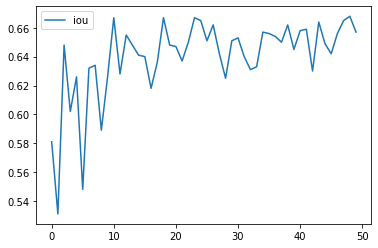

```python
d1.plot(y=["iou"])#,figsize=(40,25))
plt.show()
```

As you can see the vehicule class has performed worse after merging those 3 classe cars ,bus and vans. Next training I will only merge cars and vans and mark buses as unclassified. You can observe the new classification in the training on 14,06 session below.

## training on 14.06

```
  here is how I modify classes
   0: [255, 255, 255],  # white unclassified
    1: [153, 255, 153],  # light green natural ground
    2: [0, 204, 0],  # green low vegetation
    3: [0, 102, 0],  # dark green high vegetation
    4: [102, 0, 0],  # dark red buildings
    5: [0, 76, 153],  # blue road
    6: [6, 96, 96],  # grey wire structure
    7: [255, 69, 0],  # orangered cars
    7: [255, 140, 0],  # darkorange van
    0: [255, 127, 80],  # coral bus
    0: [219, 112, 147],  # PaleVioletRed bike
    8: [128, 0, 128],  # Purple trash can
    9: [128, 0, 0],  # maron street signs
    10: [160, 82, 45],  #Sienna lamps
    11: [128, 128, 0],  # olive remaining hard scapes
    0: [255, 235, 205],  # BlanchedAlmond crane
    4: [65, 105, 225],  # RoyalBlue greenhouses
    0: [255, 255, 0],  # yellow wall
    12: [102, 255, 255],  #  light blue manmade terrain
    5: [72, 61, 139],  # DarkSlateBlue manhole cover
    0: [255, 0, 255], #Magenta persons
    0: [255, 228, 181], # Moccasin reflexions
    13: [255, 215, 0],  # gold barrier
    4: [165, 42, 42],  # maron wood_structure
    14: [176, 224, 230],  #  PowderBlue cycling_path
```

```python
def _label_to_colors(labels):
    map_label_to_color = {
        0: [255, 255, 255],  # white unclassified
        1: [153, 255, 153],  # light green natural ground
        2: [0, 204, 0],  # green low vegetation
        3: [0, 102, 0],  # dark green high vegetation
        4: [102, 0, 0],  # dark red buildings
        5: [0, 76, 153],  # blue road
        6: [6, 96, 96],  # grey wire structure
        7: [255, 69, 0],  # orangered vehicules
        8: [128, 0, 128],  # Purple trash can
        9: [128, 0, 0],  # maron street signs
        10: [160, 82, 45],  #Sienna lamps
        11: [128, 128, 0],  # olive remaining hard scapes
        12: [102, 255, 255],  #  light blue manmade terrain
        13: [255, 215, 0],  # gold barrier
        14: [176, 224, 230],  #  PowderBlue cycling_path
    }
    a = np.array([map_label_to_color[label] for label in labels]).astype(np.int32)
    return pd.DataFrame(a,columns=['R', 'G', 'B'])
```

```python
d = pd.read_csv (r'/data/semantic3d_data/shellnet/result_analysis/trainingresults.txt', delimiter=' ', header=0)
```

```python
df = d.assign(**{'f1 score': 2 * (d['precision'] * d['iou']) / ((d['precision'] + d['iou']) + 0.00001)})
```

```python
df
```

|  | precision | recall | iou | f1 score |
| --- | --- | --- | --- | --- |
| 0 | 0.732 | 0.546 | 0.455 | 0.561175 |
| 1 | 0.438 | 0.715 | 0.373 | 0.402890 |
| 2 | 0.865 | 0.808 | 0.717 | 0.784072 |
| 3 | 0.788 | 0.727 | 0.608 | 0.686390 |
| 4 | 0.708 | 0.798 | 0.601 | 0.650122 |
| ... | ... | ... | ... | ... |
| 695 | 0.382 | 0.783 | 0.346 | 0.363105 |
| 696 | 0.029 | 0.054 | 0.019 | 0.022954 |
| 697 | 0.498 | 0.522 | 0.342 | 0.405509 |
| 698 | 0.123 | 0.118 | 0.064 | 0.084188 |
| 699 | 0.378 | 0.657 | 0.316 | 0.344226 |

700 rows × 4 columns

```python
L1 = [ 'natural_ground','low_vegetation','high_vegetation','buildings','road','wire_structure','vehicules','trash_can','street_signs','lamps','remaining_hardscapes','manmade_terrain','barrier','cycling_path']
```

```python
output1 = list(islice(cycle(L1), 700))
```

```python
df['classes'] = np.array(output1)
df
```

|  | precision | recall | iou | f1 score | classes |
| --- | --- | --- | --- | --- | --- |
| 0 | 0.732 | 0.546 | 0.455 | 0.561175 | natural_ground |
| 1 | 0.438 | 0.715 | 0.373 | 0.402890 | low_vegetation |
| 2 | 0.865 | 0.808 | 0.717 | 0.784072 | high_vegetation |
| 3 | 0.788 | 0.727 | 0.608 | 0.686390 | buildings |
| 4 | 0.708 | 0.798 | 0.601 | 0.650122 | road |
| ... | ... | ... | ... | ... | ... |
| 695 | 0.382 | 0.783 | 0.346 | 0.363105 | lamps |
| 696 | 0.029 | 0.054 | 0.019 | 0.022954 | remaining_hardscapes |
| 697 | 0.498 | 0.522 | 0.342 | 0.405509 | manmade_terrain |
| 698 | 0.123 | 0.118 | 0.064 | 0.084188 | barrier |
| 699 | 0.378 | 0.657 | 0.316 | 0.344226 | cycling_path |

700 rows × 5 columns

### Classes of best epoch miou = 0.4 / OA= 70%

```python
df[476:490]
```

|  | precision | recall | iou | f1 score | classes |
| --- | --- | --- | --- | --- | --- |
| 476 | 0.637 | 0.557 | 0.423 | 0.508393 | natural_ground |
| 477 | 0.567 | 0.677 | 0.446 | 0.499269 | low_vegetation |
| 478 | 0.859 | 0.850 | 0.746 | 0.798517 | high_vegetation |
| 479 | 0.809 | 0.783 | 0.661 | 0.727545 | buildings |
| 480 | 0.863 | 0.775 | 0.690 | 0.766859 | road |
| 481 | 0.579 | 0.539 | 0.387 | 0.463914 | wire_structure |
| 482 | 0.886 | 0.824 | 0.745 | 0.809400 | vehicules |
| 483 | 0.274 | 0.384 | 0.190 | 0.224392 | trash_can |
| 484 | 0.323 | 0.334 | 0.197 | 0.244730 | street_signs |
| 485 | 0.369 | 0.819 | 0.341 | 0.354443 | lamps |
| 486 | 0.032 | 0.057 | 0.021 | 0.025354 | remaining_hardscapes |
| 487 | 0.559 | 0.498 | 0.357 | 0.435722 | manmade_terrain |
| 488 | 0.147 | 0.135 | 0.076 | 0.100193 | barrier |
| 489 | 0.342 | 0.735 | 0.305 | 0.322437 | cycling_path |

### Inspect some of classes miou evolution during training

```python
d1 = df.loc[df.classes == "vehicules"]
```

```python
d1 = d1.reset_index()
```

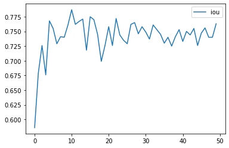

```python
d1.plot(y=["iou"])#,figsize=(40,25))
plt.show()
```

```python
d2 = df.loc[df.classes == "buildings"]
```

```python
d2 = d2.reset_index()
```

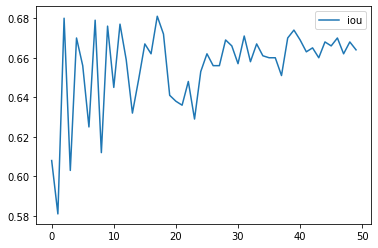

```python
d2.plot(y=["iou"])#,figsize=(40,25))
plt.show()
```

```python
d3 = df.loc[df.classes == "natural_ground"]
```

```python
d3 = d3.reset_index()
```

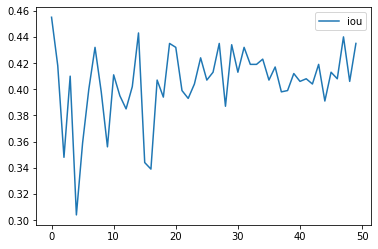

```python
d3.plot(y=["iou"])#,figsize=(40,25))
plt.show()
```

```python
df1 = pd.read_csv(r'/data/semantic3d_data/shellnet/result_analysis/iou_perclass29.05.txt',header = None, delimiter =' ',names=['precision', 'recall', 'iou', 'classes'])
```

```python
df1
```

|  | precision | recall | iou | classes |
| --- | --- | --- | --- | --- |
| 0 | 0.482 | 0.640 | 0.379 | natural_ground |
| 1 | 0.743 | 0.536 | 0.452 | low_vegetation |
| 2 | 0.842 | 0.891 | 0.764 | high_vegetation |
| 3 | 0.828 | 0.897 | 0.756 | buildings |
| 4 | 0.790 | 0.873 | 0.708 | road |
| 5 | 0.555 | 0.525 | 0.370 | wire_structure |
| 6 | 0.905 | 0.962 | 0.874 | cars |
| 7 | 0.000 | 0.000 | 0.000 | van |
| 8 | 0.000 | 0.000 | 0.000 | bus |
| 9 | 0.000 | 0.000 | 0.000 | bike |
| 10 | 0.409 | 0.522 | 0.297 | trash_can |
| 11 | 0.420 | 0.498 | 0.295 | street_signs |
| 12 | 0.861 | 0.566 | 0.519 | lamps |
| 13 | 0.030 | 0.030 | 0.015 | remaining_hardscapes |
| 14 | 0.000 | 0.000 | 0.000 | crane |
| 15 | 0.000 | 0.000 | 0.000 | greenhouses |
| 16 | 0.486 | 0.197 | 0.163 | wall |
| 17 | 0.669 | 0.591 | 0.458 | manmade_terrain |
| 18 | 0.091 | 0.012 | 0.011 | manhole_cover |
| 19 | 0.000 | 0.000 | 0.000 | persons |
| 20 | 0.000 | 0.000 | 0.000 | reflexions |
| 21 | 0.268 | 0.158 | 0.110 | barrier |
| 22 | 0.149 | 0.136 | 0.077 | wood_structure |
| 23 | 0.776 | 0.339 | 0.309 | cycling_path |

```python
df[476:490]
```

|  | precision | recall | iou | f1 score | classes |
| --- | --- | --- | --- | --- | --- |
| 476 | 0.637 | 0.557 | 0.423 | 0.508393 | natural_ground |
| 477 | 0.567 | 0.677 | 0.446 | 0.499269 | low_vegetation |
| 478 | 0.859 | 0.850 | 0.746 | 0.798517 | high_vegetation |
| 479 | 0.809 | 0.783 | 0.661 | 0.727545 | buildings |
| 480 | 0.863 | 0.775 | 0.690 | 0.766859 | road |
| 481 | 0.579 | 0.539 | 0.387 | 0.463914 | wire_structure |
| 482 | 0.886 | 0.824 | 0.745 | 0.809400 | vehicules |
| 483 | 0.274 | 0.384 | 0.190 | 0.224392 | trash_can |
| 484 | 0.323 | 0.334 | 0.197 | 0.244730 | street_signs |
| 485 | 0.369 | 0.819 | 0.341 | 0.354443 | lamps |
| 486 | 0.032 | 0.057 | 0.021 | 0.025354 | remaining_hardscapes |
| 487 | 0.559 | 0.498 | 0.357 | 0.435722 | manmade_terrain |
| 488 | 0.147 | 0.135 | 0.076 | 0.100193 | barrier |
| 489 | 0.342 | 0.735 | 0.305 | 0.322437 | cycling_path |

## Training on 15_05

```
    here is how I modify classes
   0: [255, 255, 255],  # white unclassified 0
    1: [153, 255, 153],  # light green natural ground 1
    2: [0, 204, 0],  # green low vegetation 2
    3: [0, 102, 0],  # dark green high vegetation 3
    4: [102, 0, 0],  # dark red buildings 4
    5: [0, 76, 153],  # blue road 5
    6: [6, 96, 96],  # grey wire structure 6
    7: [255, 69, 0],  # orangered cars 7
    7: [255, 140, 0],  # darkorange van 8
    0: [255, 127, 80],  # coral bus 9
    0: [219, 112, 147],  # PaleVioletRed bike 10
    9: [128, 0, 128],  # Purple trash can 11
    9: [128, 0, 0],  # maron street signs 12
    8: [160, 82, 45],  #Sienna lamps 13
    9: [128, 128, 0],  # olive remaining hard scapes 14
    0: [255, 235, 205],  # BlanchedAlmond crane 15
    4: [65, 105, 225],  # RoyalBlue greenhouses 16
    11: [255, 255, 0],  # yellow wall 17
    10: [102, 255, 255],  #  light blue manmade terrain 18
    5: [72, 61, 139],  # DarkSlateBlue manhole cover 19
    0: [255, 0, 255], #Magenta persons 20
    0: [255, 228, 181], # Moccasin reflexions 21
    11: [255, 215, 0],  # gold barrier 22
    4: [165, 42, 42],  # maron wood_structure 23
    10: [176, 224, 230],  #  PowderBlue cycling_path 24
```

```python
import numpy as np
import pandas as pd
from itertools import cycle, islice
import matplotlib.pyplot as plt
```

```python
def _label_to_colors(labels):
    map_label_to_color = {
        0: [255, 255, 255],  # white unclassified
        1: [153, 255, 153],  # light green natural ground
        2: [0, 204, 0],  # green low vegetation
        3: [0, 102, 0],  # dark green high vegetation
        4: [102, 0, 0],  # dark red buildings
        5: [0, 76, 153],  # blue road
        6: [6, 96, 96],  # grey wire structure
        7: [255, 69, 0],  # orangered vehicules
        8: [160, 82, 45],  #Sienna lamps
        9: [128, 128, 0],  # olive remaining hard scapes
        10: [102, 255, 255],  #  light blue manmade terrain
        11: [255, 215, 0],  # gold barrier
    }
    a = np.array([map_label_to_color[label] for label in labels]).astype(np.int32)
    return pd.DataFrame(a,columns=['R', 'G', 'B'])
```

```python
d5 = pd.read_csv (r'/data/semantic3d_data/shellnet/dataset/semantic_raw/train/8010_xyz_intensity_rgb.labels', delimiter=' ', header=None)
```

```python
d5[0].unique()
```

```
array([11,  4,  7, 10,  3,  2,  5,  1,  0,  9,  6])
```

```python
d5.loc[(d5[0] == 8)] = 7
d5.loc[(d5[0] == 9)] = 0
d5.loc[(d5[0] == 10)] = 0
d5.loc[(d5[0] == 15)] = 0
d5.loc[(d5[0] == 16)] = 4
d5.loc[(d5[0] == 19)] = 5
d5.loc[(d5[0] == 20)] = 0
d5.loc[(d5[0] == 21)] = 0
d5.loc[(d5[0] == 23)] = 4
d5.loc[(d5[0] == 11)] = 9
d5.loc[(d5[0] == 12)] = 9
d5.loc[(d5[0] == 13)] = 8
d5.loc[(d5[0] == 14)] = 9
d5.loc[(d5[0] == 17)] = 11
d5.loc[(d5[0] == 18)] = 10
d5.loc[(d5[0] == 22)] = 11
d5.loc[(d5[0] == 24)] = 10
```

```python
d5.to_csv(r'/data/semantic3d_data/shellnet/dataset/semantic_raw/val/8048_xyz_intensity_rgb.labels', index = False,header = None,sep=' ')
```

```python
d = pd.read_csv (r'/data/semantic3d_data/shellnet/result_analysis/trainingresults.txt', delimiter=' ', header=0)
```

```python
d
```

|  | precision | recall | iou |
| --- | --- | --- | --- |
| 0 | 0.564 | 0.557 | 0.390 |
| 1 | 0.605 | 0.660 | 0.461 |
| 2 | 0.843 | 0.843 | 0.729 |
| 3 | 0.769 | 0.754 | 0.615 |
| 4 | 0.801 | 0.745 | 0.628 |
| ... | ... | ... | ... |
| 545 | 0.912 | 0.839 | 0.777 |
| 546 | 0.399 | 0.862 | 0.375 |
| 547 | 0.123 | 0.072 | 0.047 |
| 548 | 0.546 | 0.558 | 0.381 |
| 549 | 0.170 | 0.309 | 0.123 |

550 rows × 3 columns

```python
df = d.assign(**{'f1 score': 2 * (d['precision'] * d['iou']) / ((d['precision'] + d['iou']) + 0.00001)})
```

```python
df
```

|  | precision | recall | iou | f1 score |
| --- | --- | --- | --- | --- |
| 0 | 0.564 | 0.557 | 0.390 | 0.461127 |
| 1 | 0.605 | 0.660 | 0.461 | 0.523269 |
| 2 | 0.843 | 0.843 | 0.729 | 0.781861 |
| 3 | 0.769 | 0.754 | 0.615 | 0.683427 |
| 4 | 0.801 | 0.745 | 0.628 | 0.704023 |
| ... | ... | ... | ... | ... |
| 545 | 0.912 | 0.839 | 0.777 | 0.839100 |
| 546 | 0.399 | 0.862 | 0.375 | 0.386623 |
| 547 | 0.123 | 0.072 | 0.047 | 0.068008 |
| 548 | 0.546 | 0.558 | 0.381 | 0.448811 |
| 549 | 0.170 | 0.309 | 0.123 | 0.142726 |

550 rows × 4 columns

```python
L1 = [ 'natural_ground','low_vegetation','high_vegetation','buildings','road','wire_structure','vehicules','lamps','remaining_hardscapes','manmade_terrain','barrier']
```

```python
output2 = list(islice(cycle(L1), 550))
```

```python
df['classes'] = np.array(output2)
df
```

|  | precision | recall | iou | f1 score | classes |
| --- | --- | --- | --- | --- | --- |
| 0 | 0.564 | 0.557 | 0.390 | 0.461127 | natural_ground |
| 1 | 0.605 | 0.660 | 0.461 | 0.523269 | low_vegetation |
| 2 | 0.843 | 0.843 | 0.729 | 0.781861 | high_vegetation |
| 3 | 0.769 | 0.754 | 0.615 | 0.683427 | buildings |
| 4 | 0.801 | 0.745 | 0.628 | 0.704023 | road |
| ... | ... | ... | ... | ... | ... |
| 545 | 0.912 | 0.839 | 0.777 | 0.839100 | vehicules |
| 546 | 0.399 | 0.862 | 0.375 | 0.386623 | lamps |
| 547 | 0.123 | 0.072 | 0.047 | 0.068008 | remaining_hardscapes |
| 548 | 0.546 | 0.558 | 0.381 | 0.448811 | manmade_terrain |
| 549 | 0.170 | 0.309 | 0.123 | 0.142726 | barrier |

550 rows × 5 columns

### Classes of best epoch miou = 0.466 / OA= 70%

```python
df[319:330]
```

|  | precision | recall | iou | f1 score | classes |
| --- | --- | --- | --- | --- | --- |
| 319 | 0.652 | 0.538 | 0.418 | 0.509408 | natural_ground |
| 320 | 0.555 | 0.670 | 0.436 | 0.488350 | low_vegetation |
| 321 | 0.879 | 0.843 | 0.755 | 0.812290 | high_vegetation |
| 322 | 0.808 | 0.799 | 0.671 | 0.733150 | buildings |
| 323 | 0.838 | 0.799 | 0.692 | 0.758029 | road |
| 324 | 0.609 | 0.577 | 0.421 | 0.497838 | wire_structure |
| 325 | 0.912 | 0.852 | 0.788 | 0.845473 | vehicules |
| 326 | 0.400 | 0.871 | 0.378 | 0.388684 | lamps |
| 327 | 0.111 | 0.089 | 0.052 | 0.070818 | remaining_hardscapes |
| 328 | 0.518 | 0.619 | 0.393 | 0.446919 | manmade_terrain |
| 329 | 0.164 | 0.353 | 0.126 | 0.142505 | barrier |

### Inspect some of classes miou evolution during training

```python
d1 = df.loc[df.classes == "vehicules"]
```

```python
d1 = d1.reset_index()
```

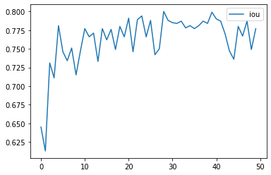

```python
d1.plot(y=["iou"])#,figsize=(40,25))
plt.show()
```

```python
d2 = df.loc[df.classes == "buildings"]
```

```python
d2 = d2.reset_index()
```

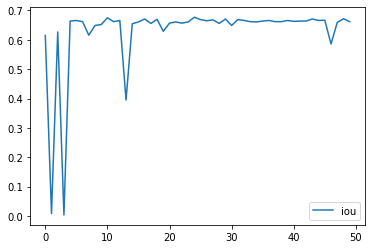

```python
d2.plot(y=["iou"])#,figsize=(40,25))
plt.show()
```

```python
d3 = df.loc[df.classes == "remaining_hardscapes"]
```

```python
d3 = d3.reset_index()
```

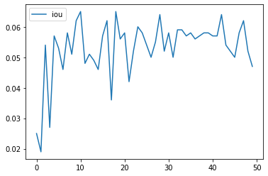

```python
d3.plot(y=["iou"])#,figsize=(40,25))
plt.show()
```

```python
d = pd.read_csv (r'/data/semantic3d_data/shellnet/result_analysis/trainingresults.txt', delimiter=' ', header=0)
```

```python
d
```

|  | precision | recall | iou |
| --- | --- | --- | --- |
| 0 | 0.663 | 0.665 | 0.497 |
| 1 | 0.510 | 0.496 | 0.336 |
| 2 | 0.816 | 0.807 | 0.683 |
| 3 | 0.826 | 0.800 | 0.685 |
| 4 | 0.665 | 0.824 | 0.582 |
| ... | ... | ... | ... |
| 545 | 0.751 | 0.823 | 0.647 |
| 546 | 0.562 | 0.782 | 0.486 |
| 547 | 0.143 | 0.238 | 0.098 |
| 548 | 0.556 | 0.498 | 0.356 |
| 549 | 0.282 | 0.302 | 0.171 |

550 rows × 3 columns

```python
df = d.assign(**{'f1 score': 2 * (d['precision'] * d['iou']) / ((d['precision'] + d['iou']) + 0.00001)})
```

```python
df
```

|  | precision | recall | iou | f1 score |
| --- | --- | --- | --- | --- |
| 0 | 0.663 | 0.665 | 0.497 | 0.568118 |
| 1 | 0.510 | 0.496 | 0.336 | 0.405102 |
| 2 | 0.816 | 0.807 | 0.683 | 0.743595 |
| 3 | 0.826 | 0.800 | 0.685 | 0.748916 |
| 4 | 0.665 | 0.824 | 0.582 | 0.620733 |
| ... | ... | ... | ... | ... |
| 545 | 0.751 | 0.823 | 0.647 | 0.695127 |
| 546 | 0.562 | 0.782 | 0.486 | 0.521239 |
| 547 | 0.143 | 0.238 | 0.098 | 0.116294 |
| 548 | 0.556 | 0.498 | 0.356 | 0.434065 |
| 549 | 0.282 | 0.302 | 0.171 | 0.212896 |

550 rows × 4 columns

```python
L1 = [ 'natural_ground','low_vegetation','high_vegetation','buildings','road','wire_structure','vehicules','lamps','remaining_hardscapes','manmade_terrain','barrier']
```

```python
output2 = list(islice(cycle(L1), 550))
```

```python
df['classes'] = np.array(output2)
df
```

|  | precision | recall | iou | f1 score | classes |
| --- | --- | --- | --- | --- | --- |
| 0 | 0.663 | 0.665 | 0.497 | 0.568118 | natural_ground |
| 1 | 0.510 | 0.496 | 0.336 | 0.405102 | low_vegetation |
| 2 | 0.816 | 0.807 | 0.683 | 0.743595 | high_vegetation |
| 3 | 0.826 | 0.800 | 0.685 | 0.748916 | buildings |
| 4 | 0.665 | 0.824 | 0.582 | 0.620733 | road |
| ... | ... | ... | ... | ... | ... |
| 545 | 0.751 | 0.823 | 0.647 | 0.695127 | vehicules |
| 546 | 0.562 | 0.782 | 0.486 | 0.521239 | lamps |
| 547 | 0.143 | 0.238 | 0.098 | 0.116294 | remaining_hardscapes |
| 548 | 0.556 | 0.498 | 0.356 | 0.434065 | manmade_terrain |
| 549 | 0.282 | 0.302 | 0.171 | 0.212896 | barrier |

550 rows × 5 columns

```python
for dataset_idx, dataset in enumerate(df):
    print(dataset)
```

```
precision
recall
iou
f1 score
classes
```

### Inspect some of classes miou evolution during training

```python
d1 = df.loc[df.classes == "manmade_terrain"]
```

```python
d1 = d1.reset_index()
```

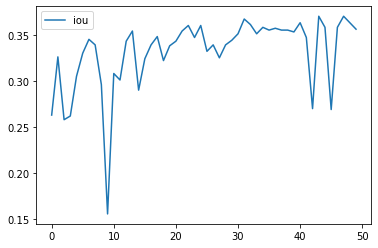

```python
d1.plot(y=["iou"])#,figsize=(40,25))
plt.show()
```

## Training on 22_06

```
    here is how I modify classes
   0: [255, 255, 255],  # white unclassified 0
    1: [153, 255, 153],  # light green natural ground 1
    2: [0, 204, 0],  # green low vegetation 2
    3: [0, 102, 0],  # dark green high vegetation 3
    4: [102, 0, 0],  # dark red buildings 4
    5: [0, 76, 153],  # blue road 5
    6: [6, 96, 96],  # grey wire structure 6
    7: [255, 69, 0],  # orangered cars 7
    7: [255, 140, 0],  # darkorange van 8
    0: [255, 127, 80],  # coral bus 9
    0: [219, 112, 147],  # PaleVioletRed bike 10
    0: [128, 0, 128],  # Purple trash can 11
    9: [128, 0, 0],  # maron street signs 12
    8: [160, 82, 45],  #Sienna lamps 13
    0: [128, 128, 0],  # olive remaining hard scapes 14
    0: [255, 235, 205],  # BlanchedAlmond crane 15
    4: [65, 105, 225],  # RoyalBlue greenhouses 16
    11: [255, 255, 0],  # yellow wall 17
    10: [102, 255, 255],  #  light blue manmade terrain 18
    5: [72, 61, 139],  # DarkSlateBlue manhole cover 19
    0: [255, 0, 255], #Magenta persons 20
    0: [255, 228, 181], # Moccasin reflexions 21
    11: [255, 215, 0],  # gold barrier 22
    0: [165, 42, 42],  # maron wood_structure 23
    10: [176, 224, 230],  #  PowderBlue cycling_path 24
```

```python
import numpy as np
import pandas as pd
from itertools import cycle, islice
import matplotlib.pyplot as plt
```

```python
def _label_to_colors(labels):
    map_label_to_color = {
        0: [255, 255, 255],  # white unclassified
        1: [153, 255, 153],  # light green natural ground
        2: [0, 204, 0],  # green low vegetation
        3: [0, 102, 0],  # dark green high vegetation
        4: [102, 0, 0],  # dark red buildings
        5: [0, 76, 153],  # blue road
        6: [6, 96, 96],  # grey wire structure
        7: [255, 69, 0],  # orangered vehicules
        8: [160, 82, 45],  #Sienna lamps
        9: [128, 0, 0],  # maron street signs
        10: [102, 255, 255],  #  light blue manmade terrain
        11: [255, 215, 0],  # gold barrier
    }
    a = np.array([map_label_to_color[label] for label in labels]).astype(np.int32)
    return pd.DataFrame(a,columns=['R', 'G', 'B'])
```

```python
d5 = pd.read_csv (r'/data/semantic3d_data/shellnet/dataset/semantic_raw/train/12_06/old_labels/8010_xyz_intensity_rgb.labels', delimiter=' ', header=None)
```

```python
d5[0].unique()
```

```
array([11,  4,  7, 10,  3,  2,  5,  1,  0,  9,  6])
```

```python
d5.loc[(d5[0] == 8)] = 7
d5.loc[(d5[0] == 9)] = 0
d5.loc[(d5[0] == 10)] = 0
d5.loc[(d5[0] == 15)] = 0
d5.loc[(d5[0] == 16)] = 4
d5.loc[(d5[0] == 19)] = 5
d5.loc[(d5[0] == 20)] = 0
d5.loc[(d5[0] == 21)] = 0
d5.loc[(d5[0] == 23)] = 0
d5.loc[(d5[0] == 11)] = 0
d5.loc[(d5[0] == 12)] = 9
d5.loc[(d5[0] == 13)] = 8
d5.loc[(d5[0] == 14)] = 0
d5.loc[(d5[0] == 17)] = 11
d5.loc[(d5[0] == 18)] = 10
d5.loc[(d5[0] == 22)] = 11
d5.loc[(d5[0] == 24)] = 10
```

```python
d5.to_csv(r'/data/semantic3d_data/shellnet/dataset/semantic_raw/train/8010_xyz_intensity_rgb.labels', index = False,header = None,sep=' ')
```

## training on big blocks : 10 x 10 m

```python
d = pd.read_csv (r'/data/semantic3d_data/shellnet/result_analysis/trainingresults.txt', delimiter=' ', header=0)
```

```python
d
```

|  | precision | recall | iou |
| --- | --- | --- | --- |
| 0 | 0.325 | 0.399 | 0.218 |
| 1 | 0.493 | 0.698 | 0.406 |
| 2 | 0.942 | 0.823 | 0.783 |
| 3 | 0.810 | 0.796 | 0.671 |
| 4 | 0.756 | 0.579 | 0.488 |
| ... | ... | ... | ... |
| 545 | 0.552 | 0.821 | 0.493 |
| 546 | 0.413 | 0.795 | 0.374 |
| 547 | 0.170 | 0.224 | 0.107 |
| 548 | 0.548 | 0.428 | 0.316 |
| 549 | 0.119 | 0.298 | 0.093 |

550 rows × 3 columns

```python
df = d.assign(**{'f1 score': 2 * (d['precision'] * d['iou']) / ((d['precision'] + d['iou']) + 0.00001)})
```

```python
df
```

|  | precision | recall | iou | f1 score |
| --- | --- | --- | --- | --- |
| 0 | 0.325 | 0.399 | 0.218 | 0.260953 |
| 1 | 0.493 | 0.698 | 0.406 | 0.445285 |
| 2 | 0.942 | 0.823 | 0.783 | 0.855167 |
| 3 | 0.810 | 0.796 | 0.671 | 0.733972 |
| 4 | 0.756 | 0.579 | 0.488 | 0.593127 |
| ... | ... | ... | ... | ... |
| 545 | 0.552 | 0.821 | 0.493 | 0.520829 |
| 546 | 0.413 | 0.795 | 0.374 | 0.392529 |
| 547 | 0.170 | 0.224 | 0.107 | 0.131331 |
| 548 | 0.548 | 0.428 | 0.316 | 0.400847 |
| 549 | 0.119 | 0.298 | 0.093 | 0.104401 |

550 rows × 4 columns

```python
L1 = [ 'natural_ground','low_vegetation','high_vegetation','buildings','road','wire_structure','vehicules','lamps','street_signs','manmade_terrain','barrier']
```

```python
output2 = list(islice(cycle(L1), 550))
```

```python
df['classes'] = np.array(output2)
df
```

|  | precision | recall | iou | f1 score | classes |
| --- | --- | --- | --- | --- | --- |
| 0 | 0.325 | 0.399 | 0.218 | 0.260953 | natural_ground |
| 1 | 0.493 | 0.698 | 0.406 | 0.445285 | low_vegetation |
| 2 | 0.942 | 0.823 | 0.783 | 0.855167 | high_vegetation |
| 3 | 0.810 | 0.796 | 0.671 | 0.733972 | buildings |
| 4 | 0.756 | 0.579 | 0.488 | 0.593127 | road |
| ... | ... | ... | ... | ... | ... |
| 545 | 0.552 | 0.821 | 0.493 | 0.520829 | vehicules |
| 546 | 0.413 | 0.795 | 0.374 | 0.392529 | lamps |
| 547 | 0.170 | 0.224 | 0.107 | 0.131331 | street_signs |
| 548 | 0.548 | 0.428 | 0.316 | 0.400847 | manmade_terrain |
| 549 | 0.119 | 0.298 | 0.093 | 0.104401 | barrier |

550 rows × 5 columns

### Classes of best epoch miou = 0.45 / OA= 71% (best epoch 20)

Note that the training has converged relatively early

```python
df[220:231]
```

|  | precision | recall | iou | f1 score | classes |
| --- | --- | --- | --- | --- | --- |
| 220 | 0.611 | 0.490 | 0.373 | 0.463213 | natural_ground |
| 221 | 0.550 | 0.696 | 0.444 | 0.491343 | low_vegetation |
| 222 | 0.912 | 0.871 | 0.803 | 0.854031 | high_vegetation |
| 223 | 0.847 | 0.838 | 0.728 | 0.782999 | buildings |
| 224 | 0.792 | 0.768 | 0.640 | 0.707928 | road |
| 225 | 0.590 | 0.681 | 0.462 | 0.518208 | wire_structure |
| 226 | 0.691 | 0.825 | 0.603 | 0.644003 | vehicules |
| 227 | 0.437 | 0.764 | 0.385 | 0.409350 | lamps |
| 228 | 0.224 | 0.287 | 0.144 | 0.175300 | street_signs |
| 229 | 0.525 | 0.422 | 0.305 | 0.385839 | manmade_terrain |
| 230 | 0.087 | 0.276 | 0.071 | 0.078185 | barrier |

### Inspect some of classes miou evolution during training

```python
d1 = df.loc[df.classes == "road"]
```

```python
d1 = d1.reset_index()
```

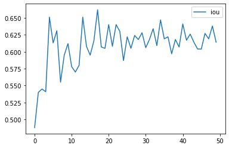

```python
d1.plot(y=["iou"])#,figsize=(40,25))
plt.show()
```

## Training on big blocks : 15 x 15 m

```python
d = pd.read_csv (r'/data/semantic3d_data/shellnet/result_analysis/trainingresults.txt', delimiter=' ', header=0)
```

```python
d
```

|  | precision | recall | iou |
| --- | --- | --- | --- |
| 0 | 0.640 | 0.469 | 0.371 |
| 1 | 0.529 | 0.736 | 0.445 |
| 2 | 0.938 | 0.849 | 0.804 |
| 3 | 0.863 | 0.734 | 0.657 |
| 4 | 0.692 | 0.766 | 0.571 |
| ... | ... | ... | ... |
| 545 | 0.335 | 0.743 | 0.300 |
| 546 | 0.245 | 0.726 | 0.225 |
| 547 | 0.095 | 0.071 | 0.042 |
| 548 | 0.359 | 0.397 | 0.232 |
| 549 | 0.081 | 0.245 | 0.065 |

550 rows × 3 columns

```python
df = d.assign(**{'f1 score': 2 * (d['precision'] * d['iou']) / ((d['precision'] + d['iou']) + 0.00001)})
```

```python
df
```

|  | precision | recall | iou | f1 score |
| --- | --- | --- | --- | --- |
| 0 | 0.640 | 0.469 | 0.371 | 0.469709 |
| 1 | 0.529 | 0.736 | 0.445 | 0.483373 |
| 2 | 0.938 | 0.849 | 0.804 | 0.865841 |
| 3 | 0.863 | 0.734 | 0.657 | 0.746036 |
| 4 | 0.692 | 0.766 | 0.571 | 0.625699 |
| ... | ... | ... | ... | ... |
| 545 | 0.335 | 0.743 | 0.300 | 0.316530 |
| 546 | 0.245 | 0.726 | 0.225 | 0.234569 |
| 547 | 0.095 | 0.071 | 0.042 | 0.058244 |
| 548 | 0.359 | 0.397 | 0.232 | 0.281850 |
| 549 | 0.081 | 0.245 | 0.065 | 0.072118 |

550 rows × 4 columns

```python
L1 = [ 'natural_ground','low_vegetation','high_vegetation','buildings','road','wire_structure','vehicules','lamps','street_signs','manmade_terrain','barrier']
```

```python
output2 = list(islice(cycle(L1), 550))
```

```python
df['classes'] = np.array(output2)
df
```

|  | precision | recall | iou | f1 score | classes |
| --- | --- | --- | --- | --- | --- |
| 0 | 0.640 | 0.469 | 0.371 | 0.469709 | natural_ground |
| 1 | 0.529 | 0.736 | 0.445 | 0.483373 | low_vegetation |
| 2 | 0.938 | 0.849 | 0.804 | 0.865841 | high_vegetation |
| 3 | 0.863 | 0.734 | 0.657 | 0.746036 | buildings |
| 4 | 0.692 | 0.766 | 0.571 | 0.625699 | road |
| ... | ... | ... | ... | ... | ... |
| 545 | 0.335 | 0.743 | 0.300 | 0.316530 | vehicules |
| 546 | 0.245 | 0.726 | 0.225 | 0.234569 | lamps |
| 547 | 0.095 | 0.071 | 0.042 | 0.058244 | street_signs |
| 548 | 0.359 | 0.397 | 0.232 | 0.281850 | manmade_terrain |
| 549 | 0.081 | 0.245 | 0.065 | 0.072118 | barrier |

550 rows × 5 columns

Note that the training has converged relatively early

```python
df[110:121]
```

|  | precision | recall | iou | f1 score | classes |
| --- | --- | --- | --- | --- | --- |
| 110 | 0.582 | 0.442 | 0.336 | 0.426035 | natural_ground |
| 111 | 0.424 | 0.734 | 0.368 | 0.394015 | low_vegetation |
| 112 | 0.949 | 0.839 | 0.803 | 0.869912 | high_vegetation |
| 113 | 0.889 | 0.781 | 0.711 | 0.790094 | buildings |
| 114 | 0.813 | 0.706 | 0.608 | 0.695708 | road |
| 115 | 0.608 | 0.813 | 0.534 | 0.568597 | wire_structure |
| 116 | 0.505 | 0.828 | 0.457 | 0.479798 | vehicules |
| 117 | 0.388 | 0.790 | 0.352 | 0.369119 | lamps |
| 118 | 0.252 | 0.204 | 0.127 | 0.168882 | street_signs |
| 119 | 0.396 | 0.331 | 0.220 | 0.282853 | manmade_terrain |
| 120 | 0.100 | 0.270 | 0.079 | 0.088263 | barrier |

### Inspect some of classes miou evolution during training

```python
d1 = df.loc[df.classes == "road"]
```

```python
d1 = d1.reset_index()
```

[figure not shown]

```python
d1.plot(y=["iou"])#,figsize=(40,25))
plt.show()
```

## Training on 28/06/2021 using random sampling

```python
d = pd.read_csv (r'/data/semantic3d_data/shellnet/result_analysis/trainingresults_random.txt', delimiter=' ', header=0)
```

```python
d
```

|  | precision | recall | iou |
| --- | --- | --- | --- |
| 0 | 0.481 | 0.363 | 0.261 |
| 1 | 0.337 | 0.644 | 0.284 |
| 2 | 0.901 | 0.882 | 0.804 |
| 3 | 0.851 | 0.682 | 0.609 |
| 4 | 0.767 | 0.591 | 0.501 |
| ... | ... | ... | ... |
| 595 | 0.234 | 0.624 | 0.205 |
| 596 | 0.218 | 0.092 | 0.069 |
| 597 | 0.350 | 0.387 | 0.225 |
| 598 | 0.090 | 0.154 | 0.060 |
| 599 | 0.022 | 0.020 | 0.011 |

600 rows × 3 columns

```python
df = d.assign(**{'f1 score': 2 * (d['precision'] * d['iou']) / ((d['precision'] + d['iou']) + 0.00001)})
```

```python
df
```

|  | precision | recall | iou | f1 score |
| --- | --- | --- | --- | --- |
| 0 | 0.481 | 0.363 | 0.261 | 0.338381 |
| 1 | 0.337 | 0.644 | 0.284 | 0.308233 |
| 2 | 0.901 | 0.882 | 0.804 | 0.849736 |
| 3 | 0.851 | 0.682 | 0.609 | 0.709939 |
| 4 | 0.767 | 0.591 | 0.501 | 0.606095 |
| ... | ... | ... | ... | ... |
| 595 | 0.234 | 0.624 | 0.205 | 0.218537 |
| 596 | 0.218 | 0.092 | 0.069 | 0.104819 |
| 597 | 0.350 | 0.387 | 0.225 | 0.273908 |
| 598 | 0.090 | 0.154 | 0.060 | 0.071995 |
| 599 | 0.022 | 0.020 | 0.011 | 0.014662 |

600 rows × 4 columns

```python
L1 = [ 'natural_ground','low_vegetation','high_vegetation','buildings','road','wire_structure','vehicules','lamps','street_signs','manmade_terrain','barrier','remaining_hardsapes']
```

```python
output2 = list(islice(cycle(L1), 600))
```

```python
df['classes'] = np.array(output2)
df
```

|  | precision | recall | iou | f1 score | classes |
| --- | --- | --- | --- | --- | --- |
| 0 | 0.481 | 0.363 | 0.261 | 0.338381 | natural_ground |
| 1 | 0.337 | 0.644 | 0.284 | 0.308233 | low_vegetation |
| 2 | 0.901 | 0.882 | 0.804 | 0.849736 | high_vegetation |
| 3 | 0.851 | 0.682 | 0.609 | 0.709939 | buildings |
| 4 | 0.767 | 0.591 | 0.501 | 0.606095 | road |
| ... | ... | ... | ... | ... | ... |
| 595 | 0.234 | 0.624 | 0.205 | 0.218537 | lamps |
| 596 | 0.218 | 0.092 | 0.069 | 0.104819 | street_signs |
| 597 | 0.350 | 0.387 | 0.225 | 0.273908 | manmade_terrain |
| 598 | 0.090 | 0.154 | 0.060 | 0.071995 | barrier |
| 599 | 0.022 | 0.020 | 0.011 | 0.014662 | remaining_hardsapes |

600 rows × 5 columns

### Classes of best epoch miou = 0.3875 / OA= 68% (best epoch = 7)

Note that the training has excluded 1 val set for the final training which is 8050 file

```python
df[84:96]
```

|  | precision | recall | iou | f1 score | classes |
| --- | --- | --- | --- | --- | --- |
| 84 | 0.603 | 0.443 | 0.343 | 0.437266 | natural_ground |
| 85 | 0.468 | 0.715 | 0.395 | 0.428408 | low_vegetation |
| 86 | 0.929 | 0.873 | 0.819 | 0.870534 | high_vegetation |
| 87 | 0.854 | 0.723 | 0.644 | 0.734275 | buildings |
| 88 | 0.722 | 0.724 | 0.566 | 0.634548 | road |
| 89 | 0.628 | 0.856 | 0.568 | 0.596490 | wire_structure |
| 90 | 0.831 | 0.695 | 0.609 | 0.702883 | vehicules |
| 91 | 0.337 | 0.562 | 0.267 | 0.297939 | lamps |
| 92 | 0.579 | 0.117 | 0.107 | 0.180618 | street_signs |
| 93 | 0.529 | 0.367 | 0.277 | 0.363601 | manmade_terrain |
| 94 | 0.068 | 0.206 | 0.054 | 0.060192 | barrier |
| 95 | 0.004 | 0.002 | 0.001 | 0.001597 | remaining_hardsapes |

Random sampling has accelerated the training time so more epoch could be conducted but it it has stoped converging very early. Hence, this method of simpling does not fit our data and using fps at this point will be better

## Training on 01/07/2021 shell size of 8 at deeper layers

```
    here is how I modify classes
   0: [255, 255, 255],  # white unclassified 0
    1: [153, 255, 153],  # light green natural ground 1
    2: [0, 204, 0],  # green low vegetation 2
    3: [0, 102, 0],  # dark green high vegetation 3
    4: [102, 0, 0],  # dark red buildings 4
    5: [0, 76, 153],  # blue road 5
    6: [6, 96, 96],  # grey wire structure 6
    7: [255, 69, 0],  # orangered cars 7
    7: [255, 140, 0],  # darkorange van 8
    0: [255, 127, 80],  # coral bus 9
    0: [219, 112, 147],  # PaleVioletRed bike 10
    12: [128, 0, 128],  # Purple trash can 11
    9: [128, 0, 0],  # maron street signs 12
    8: [160, 82, 45],  #Sienna lamps 13
    12: [128, 128, 0],  # olive remaining hard scapes 14
    0: [255, 235, 205],  # BlanchedAlmond crane 15
    4: [65, 105, 225],  # RoyalBlue greenhouses 16
    11: [255, 255, 0],  # yellow wall 17
    10: [102, 255, 255],  #  light blue manmade terrain 18
    5: [72, 61, 139],  # DarkSlateBlue manhole cover 19
    0: [255, 0, 255], #Magenta persons 20
    0: [255, 228, 181], # Moccasin reflexions 21
    11: [255, 215, 0],  # gold barrier 22
    0: [165, 42, 42],  # maron wood_structure 23
    10: [176, 224, 230],  #  PowderBlue cycling_path 24
```

```python
import numpy as np
import pandas as pd
from itertools import cycle, islice
import matplotlib.pyplot as plt
```

```python
def _label_to_colors(labels):
    map_label_to_color = {
        0: [255, 255, 255],  # white unclassified
        1: [153, 255, 153],  # light green natural ground
        2: [0, 204, 0],  # green low vegetation
        3: [0, 102, 0],  # dark green high vegetation
        4: [102, 0, 0],  # dark red buildings
        5: [0, 76, 153],  # blue road
        6: [6, 96, 96],  # grey wire structure
        7: [255, 69, 0],  # orangered vehicules
        8: [160, 82, 45],  #Sienna lamps
        9: [128, 0, 0],  # maron street signs
        10: [102, 255, 255],  #  light blue manmade terrain
        11: [255, 215, 0],  # gold barrier
        12: [128, 128, 0],  # remaining hard scapes
    }
    a = np.array([map_label_to_color[label] for label in labels]).astype(np.int32)
    return pd.DataFrame(a,columns=['R', 'G', 'B'])
```

```python
d5 = pd.read_csv (r'/data/semantic3d_data/convpoint/examples/semantic3d/data/TRAIN/8050_xyz_intensity_rgb.labels', delimiter=' ', header=None)
```

this is how I changed the architecture  
`sconv_params = [dict(zip(sconv_param_name, sconv_param)) for sconv_param in`

```
[
                 (ss*4, 4, 512, 128),
                 (ss*4, 4, 512, 128),
                 (ss*2, 2, 128, 256),
                 (ss*2, 2, 128, 256),
                 (ss*1, 1, 32, 512),
                 (ss*1, 1, 32, 512)]]
```

`sdconv_param_name = ('K', 'D', 'pts_layer_idx', 'qrs_layer_idx')`  
`sdconv_params = [dict(zip(sdconv_param_name, sdconv_param)) for sdconv_param in`

```
[
                (ss*1,  1, 5, 4),
                (ss*2,  2, 3, 2),
                (ss*4,  4, 1, 0),
                (ss*4,  4, 1, -1)]]
```

```python
d5[0].unique()
```

```
array([11,  0,  4,  7,  3,  8,  2,  5, 10,  1, 12,  9])
```

```python
d5.loc[(d5[0] == 8)] = 7
d5.loc[(d5[0] == 9)] = 0
d5.loc[(d5[0] == 10)] = 0
d5.loc[(d5[0] == 15)] = 0
d5.loc[(d5[0] == 16)] = 4
d5.loc[(d5[0] == 19)] = 5
d5.loc[(d5[0] == 20)] = 0
d5.loc[(d5[0] == 21)] = 0
d5.loc[(d5[0] == 23)] = 0
d5.loc[(d5[0] == 12)] = 9
d5.loc[(d5[0] == 11)] = 12
d5.loc[(d5[0] == 13)] = 8
d5.loc[(d5[0] == 14)] = 12
d5.loc[(d5[0] == 17)] = 11
d5.loc[(d5[0] == 18)] = 10
d5.loc[(d5[0] == 22)] = 11
d5.loc[(d5[0] == 24)] = 10
```

```python
d5.to_csv(r'/data/semantic3d_data/convpoint/examples/semantic3d/data/TRAIN/8050_xyz_intensity_rgb.labels', index = False,header = None,sep=' ')
```

```python
d = pd.read_csv (r'/data/semantic3d_data/shellnet/result_analysis/trainingresults_deepss8.txt', delimiter=' ', header=0)
```

```python
d
```

|  | precision | recall | iou |
| --- | --- | --- | --- |
| 0 | 0.595 | 0.426 | 0.331 |
| 1 | 0.530 | 0.601 | 0.392 |
| 2 | 0.850 | 0.912 | 0.785 |
| 3 | 0.672 | 0.807 | 0.578 |
| 4 | 0.749 | 0.743 | 0.595 |
| ... | ... | ... | ... |
| 595 | 0.295 | 0.642 | 0.254 |
| 596 | 0.323 | 0.038 | 0.035 |
| 597 | 0.418 | 0.481 | 0.288 |
| 598 | 0.121 | 0.389 | 0.102 |
| 599 | 0.021 | 0.064 | 0.016 |

600 rows × 3 columns

```python
df = d.assign(**{'f1 score': 2 * (d['precision'] * d['iou']) / ((d['precision'] + d['iou']) + 0.00001)})
```

```python
df
```

|  | precision | recall | iou | f1 score |
| --- | --- | --- | --- | --- |
| 0 | 0.595 | 0.426 | 0.331 | 0.425363 |
| 1 | 0.530 | 0.601 | 0.392 | 0.450668 |
| 2 | 0.850 | 0.912 | 0.785 | 0.816203 |
| 3 | 0.672 | 0.807 | 0.578 | 0.621461 |
| 4 | 0.749 | 0.743 | 0.595 | 0.663172 |
| ... | ... | ... | ... | ... |
| 595 | 0.295 | 0.642 | 0.254 | 0.272964 |
| 596 | 0.323 | 0.038 | 0.035 | 0.063155 |
| 597 | 0.418 | 0.481 | 0.288 | 0.341026 |
| 598 | 0.121 | 0.389 | 0.102 | 0.110686 |
| 599 | 0.021 | 0.064 | 0.016 | 0.018157 |

600 rows × 4 columns

```python
L1 = [ 'natural_ground','low_vegetation','high_vegetation','buildings','road','wire_structure','vehicules','lamps','street_signs','manmade_terrain','barrier','remaining_hardsapes']
```

```python
output2 = list(islice(cycle(L1), 600))
```

```python
df['classes'] = np.array(output2)
df
```

|  | precision | recall | iou | f1 score | classes |
| --- | --- | --- | --- | --- | --- |
| 0 | 0.595 | 0.426 | 0.331 | 0.425363 | natural_ground |
| 1 | 0.530 | 0.601 | 0.392 | 0.450668 | low_vegetation |
| 2 | 0.850 | 0.912 | 0.785 | 0.816203 | high_vegetation |
| 3 | 0.672 | 0.807 | 0.578 | 0.621461 | buildings |
| 4 | 0.749 | 0.743 | 0.595 | 0.663172 | road |
| ... | ... | ... | ... | ... | ... |
| 595 | 0.295 | 0.642 | 0.254 | 0.272964 | lamps |
| 596 | 0.323 | 0.038 | 0.035 | 0.063155 | street_signs |
| 597 | 0.418 | 0.481 | 0.288 | 0.341026 | manmade_terrain |
| 598 | 0.121 | 0.389 | 0.102 | 0.110686 | barrier |
| 599 | 0.021 | 0.064 | 0.016 | 0.018157 | remaining_hardsapes |

600 rows × 5 columns

Note that the training has excluded 1 val set for the final training which is 8050 file

```python
df[492:504]
```

|  | precision | recall | iou | f1 score | classes |
| --- | --- | --- | --- | --- | --- |
| 492 | 0.598 | 0.492 | 0.370 | 0.457144 | natural_ground |
| 493 | 0.545 | 0.718 | 0.449 | 0.492359 | low_vegetation |
| 494 | 0.926 | 0.876 | 0.819 | 0.869215 | high_vegetation |
| 495 | 0.780 | 0.829 | 0.671 | 0.721401 | buildings |
| 496 | 0.878 | 0.720 | 0.655 | 0.750276 | road |
| 497 | 0.516 | 0.466 | 0.324 | 0.398052 | wire_structure |
| 498 | 0.763 | 0.783 | 0.630 | 0.690146 | vehicules |
| 499 | 0.331 | 0.664 | 0.283 | 0.305119 | lamps |
| 500 | 0.362 | 0.058 | 0.053 | 0.092460 | street_signs |
| 501 | 0.401 | 0.545 | 0.301 | 0.343873 | manmade_terrain |
| 502 | 0.118 | 0.326 | 0.095 | 0.105253 | barrier |
| 503 | 0.033 | 0.069 | 0.023 | 0.027102 | remaining_hardsapes |

### Inspect some of classes miou evolution during training

```python
d1 = df.loc[df.classes == "street_signs"]
```

```python
d1 = d1.reset_index()
```

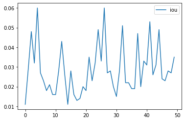

```python
d1.plot(y=["iou"])#,figsize=(40,25))
plt.show()
```

No improvemnént is observed

## Training on 03/07/2021 shell size of 16 at deeper layers

```python
d = pd.read_csv (r'/data/semantic3d_data/shellnet/result_analysis/trainingresults_deep_ss16.txt', delimiter=' ', header=0)
```

```python
d
```

|  | precision | recall | iou |
| --- | --- | --- | --- |
| 0 | 0.561 | 0.378 | 0.292 |
| 1 | 0.436 | 0.656 | 0.355 |
| 2 | 0.904 | 0.873 | 0.799 |
| 3 | 0.788 | 0.671 | 0.568 |
| 4 | 0.760 | 0.730 | 0.593 |
| ... | ... | ... | ... |
| 595 | 0.265 | 0.756 | 0.244 |
| 596 | 0.314 | 0.046 | 0.042 |
| 597 | 0.484 | 0.513 | 0.332 |
| 598 | 0.118 | 0.301 | 0.093 |
| 599 | 0.016 | 0.029 | 0.010 |

600 rows × 3 columns

```python
df = d.assign(**{'f1 score': 2 * (d['precision'] * d['iou']) / ((d['precision'] + d['iou']) + 0.00001)})
```

```python
df
```

|  | precision | recall | iou | f1 score |
| --- | --- | --- | --- | --- |
| 0 | 0.561 | 0.378 | 0.292 | 0.384080 |
| 1 | 0.436 | 0.656 | 0.355 | 0.391348 |
| 2 | 0.904 | 0.873 | 0.799 | 0.848258 |
| 3 | 0.788 | 0.671 | 0.568 | 0.660149 |
| 4 | 0.760 | 0.730 | 0.593 | 0.666189 |
| ... | ... | ... | ... | ... |
| 595 | 0.265 | 0.756 | 0.244 | 0.254062 |
| 596 | 0.314 | 0.046 | 0.042 | 0.074088 |
| 597 | 0.484 | 0.513 | 0.332 | 0.393838 |
| 598 | 0.118 | 0.301 | 0.093 | 0.104014 |
| 599 | 0.016 | 0.029 | 0.010 | 0.012303 |

600 rows × 4 columns

```python
L1 = [ 'natural_ground','low_vegetation','high_vegetation','buildings','road','wire_structure','vehicules','lamps','street_signs','manmade_terrain','barrier','remaining_hardsapes']
```

```python
output2 = list(islice(cycle(L1), 600))
```

```python
df['classes'] = np.array(output2)
df
```

|  | precision | recall | iou | f1 score | classes |
| --- | --- | --- | --- | --- | --- |
| 0 | 0.561 | 0.378 | 0.292 | 0.384080 | natural_ground |
| 1 | 0.436 | 0.656 | 0.355 | 0.391348 | low_vegetation |
| 2 | 0.904 | 0.873 | 0.799 | 0.848258 | high_vegetation |
| 3 | 0.788 | 0.671 | 0.568 | 0.660149 | buildings |
| 4 | 0.760 | 0.730 | 0.593 | 0.666189 | road |
| ... | ... | ... | ... | ... | ... |
| 595 | 0.265 | 0.756 | 0.244 | 0.254062 | lamps |
| 596 | 0.314 | 0.046 | 0.042 | 0.074088 | street_signs |
| 597 | 0.484 | 0.513 | 0.332 | 0.393838 | manmade_terrain |
| 598 | 0.118 | 0.301 | 0.093 | 0.104014 | barrier |
| 599 | 0.016 | 0.029 | 0.010 | 0.012303 | remaining_hardsapes |

600 rows × 5 columns

### Classes of best epoch miou = 0.391 / OA= 70.4% (best epoch 48)

Note that the training has excluded 1 val set for the final training which is 8050 file

```python
df[576:588]
```

|  | precision | recall | iou | f1 score | classes |
| --- | --- | --- | --- | --- | --- |
| 576 | 0.604 | 0.476 | 0.363 | 0.453464 | natural_ground |
| 577 | 0.505 | 0.717 | 0.421 | 0.459185 | low_vegetation |
| 578 | 0.938 | 0.842 | 0.797 | 0.861766 | high_vegetation |
| 579 | 0.849 | 0.805 | 0.705 | 0.770323 | buildings |
| 580 | 0.821 | 0.749 | 0.644 | 0.721803 | road |
| 581 | 0.656 | 0.570 | 0.439 | 0.525993 | wire_structure |
| 582 | 0.750 | 0.723 | 0.583 | 0.656034 | vehicules |
| 583 | 0.279 | 0.764 | 0.257 | 0.267544 | lamps |
| 584 | 0.338 | 0.051 | 0.047 | 0.082523 | street_signs |
| 585 | 0.475 | 0.527 | 0.333 | 0.391517 | manmade_terrain |
| 586 | 0.119 | 0.302 | 0.093 | 0.104401 | barrier |
| 587 | 0.019 | 0.036 | 0.013 | 0.015433 | remaining_hardsapes |

## Training on 03/07/2021 with adam at deeper layers

```python
d = pd.read_csv (r'/data/semantic3d_data/shellnet/result_analysis/trainingresults_deepadam.txt', delimiter=' ', header=0)
```

```python
d
```

|  | precision | recall | iou |
| --- | --- | --- | --- |
| 0 | 0.696 | 0.355 | 0.307 |
| 1 | 0.448 | 0.600 | 0.345 |
| 2 | 0.864 | 0.896 | 0.785 |
| 3 | 0.770 | 0.754 | 0.615 |
| 4 | 0.391 | 0.687 | 0.332 |
| ... | ... | ... | ... |
| 2395 | 0.200 | 0.152 | 0.095 |
| 2396 | 0.163 | 0.048 | 0.038 |
| 2397 | 0.526 | 0.257 | 0.209 |
| 2398 | 0.087 | 0.282 | 0.071 |
| 2399 | 0.006 | 0.012 | 0.004 |

2400 rows × 3 columns

```python
df = d.assign(**{'f1 score': 2 * (d['precision'] * d['iou']) / ((d['precision'] + d['iou']) + 0.00001)})
```

```python
df
```

|  | precision | recall | iou | f1 score |
| --- | --- | --- | --- | --- |
| 0 | 0.696 | 0.355 | 0.307 | 0.426062 |
| 1 | 0.448 | 0.600 | 0.345 | 0.389806 |
| 2 | 0.864 | 0.896 | 0.785 | 0.822603 |
| 3 | 0.770 | 0.754 | 0.615 | 0.683822 |
| 4 | 0.391 | 0.687 | 0.332 | 0.359088 |
| ... | ... | ... | ... | ... |
| 2395 | 0.200 | 0.152 | 0.095 | 0.128809 |
| 2396 | 0.163 | 0.048 | 0.038 | 0.061629 |
| 2397 | 0.526 | 0.257 | 0.209 | 0.299136 |
| 2398 | 0.087 | 0.282 | 0.071 | 0.078185 |
| 2399 | 0.006 | 0.012 | 0.004 | 0.004795 |

2400 rows × 4 columns

```python
L1 = [ 'natural_ground','low_vegetation','high_vegetation','buildings','road','wire_structure','vehicules','lamps','street_signs','manmade_terrain','barrier','remaining_hardsapes']
```

```python
output2 = list(islice(cycle(L1), 2400))
```

```python
df['classes'] = np.array(output2)
df
```

|  | precision | recall | iou | f1 score | classes |
| --- | --- | --- | --- | --- | --- |
| 0 | 0.696 | 0.355 | 0.307 | 0.426062 | natural_ground |
| 1 | 0.448 | 0.600 | 0.345 | 0.389806 | low_vegetation |
| 2 | 0.864 | 0.896 | 0.785 | 0.822603 | high_vegetation |
| 3 | 0.770 | 0.754 | 0.615 | 0.683822 | buildings |
| 4 | 0.391 | 0.687 | 0.332 | 0.359088 | road |
| ... | ... | ... | ... | ... | ... |
| 2395 | 0.200 | 0.152 | 0.095 | 0.128809 | lamps |
| 2396 | 0.163 | 0.048 | 0.038 | 0.061629 | street_signs |
| 2397 | 0.526 | 0.257 | 0.209 | 0.299136 | manmade_terrain |
| 2398 | 0.087 | 0.282 | 0.071 | 0.078185 | barrier |
| 2399 | 0.006 | 0.012 | 0.004 | 0.004795 | remaining_hardsapes |

2400 rows × 5 columns

Note that the training has excluded 1 val set for the final training which is 8050 file

```python
df[144:156]
```

|  | precision | recall | iou | f1 score | classes |
| --- | --- | --- | --- | --- | --- |
| 144 | 0.632 | 0.445 | 0.354 | 0.453805 | natural_ground |
| 145 | 0.467 | 0.702 | 0.390 | 0.425036 | low_vegetation |
| 146 | 0.922 | 0.864 | 0.805 | 0.859532 | high_vegetation |
| 147 | 0.854 | 0.720 | 0.641 | 0.732322 | buildings |
| 148 | 0.788 | 0.778 | 0.643 | 0.708149 | road |
| 149 | 0.682 | 0.499 | 0.405 | 0.508201 | wire_structure |
| 150 | 0.751 | 0.709 | 0.574 | 0.650673 | vehicules |
| 151 | 0.232 | 0.758 | 0.216 | 0.223709 | lamps |
| 152 | 0.247 | 0.145 | 0.101 | 0.143369 | street_signs |
| 153 | 0.530 | 0.504 | 0.348 | 0.420132 | manmade_terrain |
| 154 | 0.121 | 0.295 | 0.094 | 0.105800 | barrier |
| 155 | 0.031 | 0.052 | 0.020 | 0.024309 | remaining_hardsapes |

## Training on 8/07/2021 shell size 8 at 4 kernels conv deconv with random

here is how I changed the architechture  
`sconv_params = [dict(zip(sconv_param_name, sconv_param)) for sconv_param in`

```
[
                 (ss*8, 8, 1024, 64),
                 (ss*4, 4, 512, 128),
                 (ss*2, 2, 128, 256),
                 (ss*1, 1, 32, 512)]]
```

`sdconv_param_name = ('K', 'D', 'pts_layer_idx', 'qrs_layer_idx')`  
`sdconv_params = [dict(zip(sdconv_param_name, sdconv_param)) for sdconv_param in`

```
[
                (ss*1,  1, 3, 2),
                (ss*2,  2, 2, 1),
                (ss*4,  4, 1, 0),
                (ss*4,  4, 0, -1)]]
```

```python
d = pd.read_csv (r'/data/semantic3d_data/shellnet/result_analysis/trainingresults_deep1random.txt', delimiter=' ', header=0)
```

```python
d
```

|  | precision | recall | iou |
| --- | --- | --- | --- |
| 0 | 0.594 | 0.420 | 0.326 |
| 1 | 0.434 | 0.597 | 0.336 |
| 2 | 0.857 | 0.893 | 0.777 |
| 3 | 0.693 | 0.698 | 0.533 |
| 4 | 0.898 | 0.664 | 0.617 |
| ... | ... | ... | ... |
| 595 | 0.363 | 0.802 | 0.333 |
| 596 | 0.504 | 0.122 | 0.109 |
| 597 | 0.447 | 0.495 | 0.307 |
| 598 | 0.142 | 0.174 | 0.085 |
| 599 | 0.031 | 0.045 | 0.019 |

600 rows × 3 columns

```python
df = d.assign(**{'f1 score': 2 * (d['precision'] * d['iou']) / ((d['precision'] + d['iou']) + 0.00001)})
```

```python
df
```

|  | precision | recall | iou | f1 score |
| --- | --- | --- | --- | --- |
| 0 | 0.594 | 0.420 | 0.326 | 0.420961 |
| 1 | 0.434 | 0.597 | 0.336 | 0.378759 |
| 2 | 0.857 | 0.893 | 0.777 | 0.815037 |
| 3 | 0.693 | 0.698 | 0.533 | 0.602555 |
| 4 | 0.898 | 0.664 | 0.617 | 0.731435 |
| ... | ... | ... | ... | ... |
| 595 | 0.363 | 0.802 | 0.333 | 0.347348 |
| 596 | 0.504 | 0.122 | 0.109 | 0.179234 |
| 597 | 0.447 | 0.495 | 0.307 | 0.363998 |
| 598 | 0.142 | 0.174 | 0.085 | 0.106339 |
| 599 | 0.031 | 0.045 | 0.019 | 0.023555 |

600 rows × 4 columns

```python
L1 = [ 'natural_ground','low_vegetation','high_vegetation','buildings','road','wire_structure','vehicules','lamps','street_signs','manmade_terrain','barrier','remaining_hardsapes']
```

```python
output2 = list(islice(cycle(L1), 600))
```

```python
df['classes'] = np.array(output2)
df
```

|  | precision | recall | iou | f1 score | classes |
| --- | --- | --- | --- | --- | --- |
| 0 | 0.594 | 0.420 | 0.326 | 0.420961 | natural_ground |
| 1 | 0.434 | 0.597 | 0.336 | 0.378759 | low_vegetation |
| 2 | 0.857 | 0.893 | 0.777 | 0.815037 | high_vegetation |
| 3 | 0.693 | 0.698 | 0.533 | 0.602555 | buildings |
| 4 | 0.898 | 0.664 | 0.617 | 0.731435 | road |
| ... | ... | ... | ... | ... | ... |
| 595 | 0.363 | 0.802 | 0.333 | 0.347348 | lamps |
| 596 | 0.504 | 0.122 | 0.109 | 0.179234 | street_signs |
| 597 | 0.447 | 0.495 | 0.307 | 0.363998 | manmade_terrain |
| 598 | 0.142 | 0.174 | 0.085 | 0.106339 | barrier |
| 599 | 0.031 | 0.045 | 0.019 | 0.023555 | remaining_hardsapes |

600 rows × 5 columns

### Classes of best epoch miou = 0.40 / OA= 69.0% (best epoch 26)

Note that the training has excluded 1 val set for the final training which is 8050 file

```python
df[312:324]
```

|  | precision | recall | iou | f1 score | classes |
| --- | --- | --- | --- | --- | --- |
| 312 | 0.586 | 0.442 | 0.337 | 0.427909 | natural_ground |
| 313 | 0.498 | 0.700 | 0.411 | 0.450332 | low_vegetation |
| 314 | 0.920 | 0.875 | 0.813 | 0.863192 | high_vegetation |
| 315 | 0.874 | 0.718 | 0.650 | 0.745533 | buildings |
| 316 | 0.787 | 0.753 | 0.625 | 0.696702 | road |
| 317 | 0.707 | 0.566 | 0.458 | 0.555885 | wire_structure |
| 318 | 0.799 | 0.747 | 0.629 | 0.703876 | vehicules |
| 319 | 0.399 | 0.755 | 0.353 | 0.374588 | lamps |
| 320 | 0.388 | 0.177 | 0.138 | 0.203585 | street_signs |
| 321 | 0.485 | 0.494 | 0.324 | 0.388475 | manmade_terrain |
| 322 | 0.127 | 0.202 | 0.085 | 0.101835 | barrier |
| 323 | 0.029 | 0.042 | 0.017 | 0.021430 | remaining_hardsapes |

The improvement was minor but the architechture will be saved

## Training on 9/07/2021 shell size 8 at 4 kernels conv deconv

```python
d = pd.read_csv (r'/data/semantic3d_data/shellnet/result_analysis/trainingresults_deep1.txt', delimiter=' ', header=0)
```

```python
d
```

|  | precision | recall | iou |
| --- | --- | --- | --- |
| 0 | 0.631 | 0.443 | 0.352 |
| 1 | 0.499 | 0.650 | 0.394 |
| 2 | 0.907 | 0.841 | 0.774 |
| 3 | 0.797 | 0.726 | 0.613 |
| 4 | 0.799 | 0.810 | 0.673 |
| ... | ... | ... | ... |
| 595 | 0.400 | 0.680 | 0.336 |
| 596 | 0.405 | 0.274 | 0.196 |
| 597 | 0.485 | 0.488 | 0.322 |
| 598 | 0.118 | 0.234 | 0.085 |
| 599 | 0.063 | 0.070 | 0.034 |

600 rows × 3 columns

```python
df = d.assign(**{'f1 score': 2 * (d['precision'] * d['iou']) / ((d['precision'] + d['iou']) + 0.00001)})
```

```python
df
```

|  | precision | recall | iou | f1 score |
| --- | --- | --- | --- | --- |
| 0 | 0.631 | 0.443 | 0.352 | 0.451902 |
| 1 | 0.499 | 0.650 | 0.394 | 0.440322 |
| 2 | 0.907 | 0.841 | 0.774 | 0.835234 |
| 3 | 0.797 | 0.726 | 0.613 | 0.692989 |
| 4 | 0.799 | 0.810 | 0.673 | 0.730602 |
| ... | ... | ... | ... | ... |
| 595 | 0.400 | 0.680 | 0.336 | 0.365212 |
| 596 | 0.405 | 0.274 | 0.196 | 0.264155 |
| 597 | 0.485 | 0.488 | 0.322 | 0.387034 |
| 598 | 0.118 | 0.234 | 0.085 | 0.098813 |
| 599 | 0.063 | 0.070 | 0.034 | 0.044160 |

600 rows × 4 columns

```python
L1 = [ 'natural_ground','low_vegetation','high_vegetation','buildings','road','wire_structure','vehicules','lamps','street_signs','manmade_terrain','barrier','remaining_hardsapes']
```

```python
output2 = list(islice(cycle(L1), 600))
```

```python
df['classes'] = np.array(output2)
df
```

|  | precision | recall | iou | f1 score | classes |
| --- | --- | --- | --- | --- | --- |
| 0 | 0.631 | 0.443 | 0.352 | 0.451902 | natural_ground |
| 1 | 0.499 | 0.650 | 0.394 | 0.440322 | low_vegetation |
| 2 | 0.907 | 0.841 | 0.774 | 0.835234 | high_vegetation |
| 3 | 0.797 | 0.726 | 0.613 | 0.692989 | buildings |
| 4 | 0.799 | 0.810 | 0.673 | 0.730602 | road |
| ... | ... | ... | ... | ... | ... |
| 595 | 0.400 | 0.680 | 0.336 | 0.365212 | lamps |
| 596 | 0.405 | 0.274 | 0.196 | 0.264155 | street_signs |
| 597 | 0.485 | 0.488 | 0.322 | 0.387034 | manmade_terrain |
| 598 | 0.118 | 0.234 | 0.085 | 0.098813 | barrier |
| 599 | 0.063 | 0.070 | 0.034 | 0.044160 | remaining_hardsapes |

600 rows × 5 columns

### Classes of best epoch miou = 0.42 / OA= 71.2% (best epoch 15)

Note that the training has excluded 1 val set for the final training which is 8050 file

```python
df[180:192]
```

|  | precision | recall | iou | f1 score | classes |
| --- | --- | --- | --- | --- | --- |
| 180 | 0.539 | 0.494 | 0.347 | 0.422192 | natural_ground |
| 181 | 0.563 | 0.723 | 0.463 | 0.508122 | low_vegetation |
| 182 | 0.946 | 0.825 | 0.788 | 0.859797 | high_vegetation |
| 183 | 0.848 | 0.845 | 0.734 | 0.786888 | buildings |
| 184 | 0.813 | 0.754 | 0.643 | 0.718071 | road |
| 185 | 0.642 | 0.555 | 0.424 | 0.510704 | wire_structure |
| 186 | 0.873 | 0.809 | 0.724 | 0.791544 | vehicules |
| 187 | 0.359 | 0.704 | 0.312 | 0.333849 | lamps |
| 188 | 0.468 | 0.326 | 0.238 | 0.315531 | street_signs |
| 189 | 0.524 | 0.466 | 0.328 | 0.403451 | manmade_terrain |
| 190 | 0.080 | 0.306 | 0.068 | 0.073509 | barrier |
| 191 | 0.031 | 0.051 | 0.020 | 0.024309 | remaining_hardsapes |

## Training on 8/07/2021 shell size 8 at 4 kernels conv deconv with random

```python
d = pd.read_csv (r'/data/semantic3d_data/shellnet/result_analysis/trainingresults_deep1random.txt', delimiter=' ', header=0)
```

```python
d
```

|  | precision | recall | iou |
| --- | --- | --- | --- |
| 0 | 0.594 | 0.420 | 0.326 |
| 1 | 0.434 | 0.597 | 0.336 |
| 2 | 0.857 | 0.893 | 0.777 |
| 3 | 0.693 | 0.698 | 0.533 |
| 4 | 0.898 | 0.664 | 0.617 |
| ... | ... | ... | ... |
| 595 | 0.363 | 0.802 | 0.333 |
| 596 | 0.504 | 0.122 | 0.109 |
| 597 | 0.447 | 0.495 | 0.307 |
| 598 | 0.142 | 0.174 | 0.085 |
| 599 | 0.031 | 0.045 | 0.019 |

600 rows × 3 columns

```python
df = d.assign(**{'f1 score': 2 * (d['precision'] * d['iou']) / ((d['precision'] + d['iou']) + 0.00001)})
```

```python
df
```

|  | precision | recall | iou | f1 score |
| --- | --- | --- | --- | --- |
| 0 | 0.594 | 0.420 | 0.326 | 0.420961 |
| 1 | 0.434 | 0.597 | 0.336 | 0.378759 |
| 2 | 0.857 | 0.893 | 0.777 | 0.815037 |
| 3 | 0.693 | 0.698 | 0.533 | 0.602555 |
| 4 | 0.898 | 0.664 | 0.617 | 0.731435 |
| ... | ... | ... | ... | ... |
| 595 | 0.363 | 0.802 | 0.333 | 0.347348 |
| 596 | 0.504 | 0.122 | 0.109 | 0.179234 |
| 597 | 0.447 | 0.495 | 0.307 | 0.363998 |
| 598 | 0.142 | 0.174 | 0.085 | 0.106339 |
| 599 | 0.031 | 0.045 | 0.019 | 0.023555 |

600 rows × 4 columns

```python
L1 = [ 'natural_ground','low_vegetation','high_vegetation','buildings','road','wire_structure','vehicules','lamps','street_signs','manmade_terrain','barrier','remaining_hardsapes']
```

```python
output2 = list(islice(cycle(L1), 600))
```

```python
df['classes'] = np.array(output2)
df
```

|  | precision | recall | iou | f1 score | classes |
| --- | --- | --- | --- | --- | --- |
| 0 | 0.594 | 0.420 | 0.326 | 0.420961 | natural_ground |
| 1 | 0.434 | 0.597 | 0.336 | 0.378759 | low_vegetation |
| 2 | 0.857 | 0.893 | 0.777 | 0.815037 | high_vegetation |
| 3 | 0.693 | 0.698 | 0.533 | 0.602555 | buildings |
| 4 | 0.898 | 0.664 | 0.617 | 0.731435 | road |
| ... | ... | ... | ... | ... | ... |
| 595 | 0.363 | 0.802 | 0.333 | 0.347348 | lamps |
| 596 | 0.504 | 0.122 | 0.109 | 0.179234 | street_signs |
| 597 | 0.447 | 0.495 | 0.307 | 0.363998 | manmade_terrain |
| 598 | 0.142 | 0.174 | 0.085 | 0.106339 | barrier |
| 599 | 0.031 | 0.045 | 0.019 | 0.023555 | remaining_hardsapes |

600 rows × 5 columns

### Classes of best epoch miou = 0.40 / OA= 69.0% (best epoch 26)

Note that the training has excluded 1 val set for the final training which is 8050 file

```python
df[312:324]
```

|  | precision | recall | iou | f1 score | classes |
| --- | --- | --- | --- | --- | --- |
| 312 | 0.586 | 0.442 | 0.337 | 0.427909 | natural_ground |
| 313 | 0.498 | 0.700 | 0.411 | 0.450332 | low_vegetation |
| 314 | 0.920 | 0.875 | 0.813 | 0.863192 | high_vegetation |
| 315 | 0.874 | 0.718 | 0.650 | 0.745533 | buildings |
| 316 | 0.787 | 0.753 | 0.625 | 0.696702 | road |
| 317 | 0.707 | 0.566 | 0.458 | 0.555885 | wire_structure |
| 318 | 0.799 | 0.747 | 0.629 | 0.703876 | vehicules |
| 319 | 0.399 | 0.755 | 0.353 | 0.374588 | lamps |
| 320 | 0.388 | 0.177 | 0.138 | 0.203585 | street_signs |
| 321 | 0.485 | 0.494 | 0.324 | 0.388475 | manmade_terrain |
| 322 | 0.127 | 0.202 | 0.085 | 0.101835 | barrier |
| 323 | 0.029 | 0.042 | 0.017 | 0.021430 | remaining_hardsapes |

## Final training on 16/07/2021 shell size 8 at 4 kernels conv deconv

```python
d = pd.read_csv (r'/data/semantic3d_data/shellnet/result_analysis/trainingresults_final.txt', delimiter=' ', header=0)
```

```python
d
```

|  | precision | recall | iou |
| --- | --- | --- | --- |
| 0 | 0.699 | 0.277 | 0.248 |
| 1 | 0.441 | 0.630 | 0.351 |
| 2 | 0.936 | 0.835 | 0.790 |
| 3 | 0.861 | 0.942 | 0.818 |
| 4 | 0.720 | 0.849 | 0.638 |
| ... | ... | ... | ... |
| 595 | 0.599 | 0.845 | 0.539 |
| 596 | 0.404 | 0.662 | 0.335 |
| 597 | 0.511 | 0.495 | 0.336 |
| 598 | 0.392 | 0.418 | 0.254 |
| 599 | 0.000 | 0.000 | 0.000 |

600 rows × 3 columns

```python
df = d.assign(**{'f1 score': 2 * (d['precision'] * d['iou']) / ((d['precision'] + d['iou']) + 0.00001)})
```

```python
df
```

|  | precision | recall | iou | f1 score |
| --- | --- | --- | --- | --- |
| 0 | 0.699 | 0.277 | 0.248 | 0.366104 |
| 1 | 0.441 | 0.630 | 0.351 | 0.390881 |
| 2 | 0.936 | 0.835 | 0.790 | 0.856820 |
| 3 | 0.861 | 0.942 | 0.818 | 0.838944 |
| 4 | 0.720 | 0.849 | 0.638 | 0.676519 |
| ... | ... | ... | ... | ... |
| 595 | 0.599 | 0.845 | 0.539 | 0.567413 |
| 596 | 0.404 | 0.662 | 0.335 | 0.366274 |
| 597 | 0.511 | 0.495 | 0.336 | 0.405417 |
| 598 | 0.392 | 0.418 | 0.254 | 0.308255 |
| 599 | 0.000 | 0.000 | 0.000 | 0.000000 |

600 rows × 4 columns

```python
L1 = [ 'natural_ground','low_vegetation','high_vegetation','buildings','road','wire_structure','vehicules','lamps','street_signs','manmade_terrain','barrier','remaining_hardsapes']
```

```python
output2 = list(islice(cycle(L1), 600))
```

```python
df['classes'] = np.array(output2)
df
```

|  | precision | recall | iou | f1 score | classes |
| --- | --- | --- | --- | --- | --- |
| 0 | 0.699 | 0.277 | 0.248 | 0.366104 | natural_ground |
| 1 | 0.441 | 0.630 | 0.351 | 0.390881 | low_vegetation |
| 2 | 0.936 | 0.835 | 0.790 | 0.856820 | high_vegetation |
| 3 | 0.861 | 0.942 | 0.818 | 0.838944 | buildings |
| 4 | 0.720 | 0.849 | 0.638 | 0.676519 | road |
| ... | ... | ... | ... | ... | ... |
| 595 | 0.599 | 0.845 | 0.539 | 0.567413 | lamps |
| 596 | 0.404 | 0.662 | 0.335 | 0.366274 | street_signs |
| 597 | 0.511 | 0.495 | 0.336 | 0.405417 | manmade_terrain |
| 598 | 0.392 | 0.418 | 0.254 | 0.308255 | barrier |
| 599 | 0.000 | 0.000 | 0.000 | 0.000000 | remaining_hardsapes |

600 rows × 5 columns

### Classes of best epoch miou = 0.432 / OA= 73.9% (best epoch 21)

note that the training has included the val set for the final training which is 8050 file and move the file 4048 to training set

```python
df[252:264]
```

|  | precision | recall | iou | f1 score | classes |
| --- | --- | --- | --- | --- | --- |
| 252 | 0.380 | 0.430 | 0.253 | 0.303755 | natural_ground |
| 253 | 0.615 | 0.589 | 0.430 | 0.506120 | low_vegetation |
| 254 | 0.957 | 0.852 | 0.821 | 0.883794 | high_vegetation |
| 255 | 0.905 | 0.948 | 0.862 | 0.882972 | buildings |
| 256 | 0.824 | 0.850 | 0.719 | 0.767922 | road |
| 257 | 0.000 | 0.000 | 0.000 | 0.000000 | wire_structure |
| 258 | 0.688 | 0.849 | 0.613 | 0.648333 | vehicules |
| 259 | 0.628 | 0.824 | 0.554 | 0.588679 | lamps |
| 260 | 0.404 | 0.746 | 0.355 | 0.377913 | street_signs |
| 261 | 0.482 | 0.489 | 0.321 | 0.385355 | manmade_terrain |
| 262 | 0.425 | 0.393 | 0.257 | 0.320303 | barrier |
| 263 | 0.000 | 0.000 | 0.000 | 0.000000 | remaining_hardsapes |

wire structure does not exist in the validation set and remaining hardscape is suprisengly 0 !!!

## Final training on 21/07/2021 shell size 8 at 4 kernels conv deconv (fix rhs label on 8050)

```python
d = pd.read_csv (r'/data/semantic3d_data/shellnet/result_analysis/trainingresults.txt', delimiter=' ', header=0)
```

```python
d
```

|  | precision | recall | iou |
| --- | --- | --- | --- |
| 0 | 0.401 | 0.377 | 0.241 |
| 1 | 0.624 | 0.504 | 0.386 |
| 2 | 0.917 | 0.787 | 0.734 |
| 3 | 0.826 | 0.939 | 0.784 |
| 4 | 0.832 | 0.811 | 0.696 |
| ... | ... | ... | ... |
| 1195 | 0.657 | 0.801 | 0.565 |
| 1196 | 0.454 | 0.711 | 0.383 |
| 1197 | 0.520 | 0.461 | 0.323 |
| 1198 | 0.380 | 0.335 | 0.217 |
| 1199 | 0.089 | 0.238 | 0.070 |

1200 rows × 3 columns

```python
df = d.assign(**{'f1 score': 2 * (d['precision'] * d['iou']) / ((d['precision'] + d['iou']) + 0.00001)})
```

```python
df
```

|  | precision | recall | iou | f1 score |
| --- | --- | --- | --- | --- |
| 0 | 0.401 | 0.377 | 0.241 | 0.301058 |
| 1 | 0.624 | 0.504 | 0.386 | 0.476954 |
| 2 | 0.917 | 0.787 | 0.734 | 0.815353 |
| 3 | 0.826 | 0.939 | 0.784 | 0.804447 |
| 4 | 0.832 | 0.811 | 0.696 | 0.757943 |
| ... | ... | ... | ... | ... |
| 1195 | 0.657 | 0.801 | 0.565 | 0.607532 |
| 1196 | 0.454 | 0.711 | 0.383 | 0.415484 |
| 1197 | 0.520 | 0.461 | 0.323 | 0.398477 |
| 1198 | 0.380 | 0.335 | 0.217 | 0.276243 |
| 1199 | 0.089 | 0.238 | 0.070 | 0.078360 |

1200 rows × 4 columns

```python
L1 = [ 'natural_ground','low_vegetation','high_vegetation','buildings','road','wire_structure','vehicules','lamps','street_signs','manmade_terrain','barrier','remaining_hardsapes']
```

```python
output2 = list(islice(cycle(L1), 1200))
```

```python
df['classes'] = np.array(output2)
df
```

|  | precision | recall | iou | f1 score | classes |
| --- | --- | --- | --- | --- | --- |
| 0 | 0.401 | 0.377 | 0.241 | 0.301058 | natural_ground |
| 1 | 0.624 | 0.504 | 0.386 | 0.476954 | low_vegetation |
| 2 | 0.917 | 0.787 | 0.734 | 0.815353 | high_vegetation |
| 3 | 0.826 | 0.939 | 0.784 | 0.804447 | buildings |
| 4 | 0.832 | 0.811 | 0.696 | 0.757943 | road |
| ... | ... | ... | ... | ... | ... |
| 1195 | 0.657 | 0.801 | 0.565 | 0.607532 | lamps |
| 1196 | 0.454 | 0.711 | 0.383 | 0.415484 | street_signs |
| 1197 | 0.520 | 0.461 | 0.323 | 0.398477 | manmade_terrain |
| 1198 | 0.380 | 0.335 | 0.217 | 0.276243 | barrier |
| 1199 | 0.089 | 0.238 | 0.070 | 0.078360 | remaining_hardsapes |

1200 rows × 5 columns

### Classes of best epoch miou = 0.429 / OA= 72.6% (best epoch 22)

Note that the training has included the val set for the final training which is 8050 file and move the file 4048 to training set

```python
df[264:276]
```

|  | precision | recall | iou | f1 score | classes |
| --- | --- | --- | --- | --- | --- |
| 264 | 0.345 | 0.428 | 0.236 | 0.280271 | natural_ground |
| 265 | 0.650 | 0.565 | 0.433 | 0.519755 | low_vegetation |
| 266 | 0.954 | 0.868 | 0.832 | 0.888828 | high_vegetation |
| 267 | 0.896 | 0.923 | 0.834 | 0.863884 | buildings |
| 268 | 0.806 | 0.845 | 0.703 | 0.750980 | road |
| 269 | 0.000 | 0.000 | 0.000 | 0.000000 | wire_structure |
| 270 | 0.632 | 0.833 | 0.561 | 0.594382 | vehicules |
| 271 | 0.694 | 0.768 | 0.574 | 0.628317 | lamps |
| 272 | 0.447 | 0.691 | 0.373 | 0.406656 | street_signs |
| 273 | 0.483 | 0.476 | 0.315 | 0.381311 | manmade_terrain |
| 274 | 0.459 | 0.311 | 0.227 | 0.303765 | barrier |
| 275 | 0.073 | 0.217 | 0.058 | 0.064636 | remaining_hardsapes |

## merge and check the test data using label to color function (applies for the other 2 models)

```python
d10 = pd.read_csv (r'/data/semantic3d_data/convpoint/examples/semantic3d/data/TEST/rescaled_8054_8055_106267_106281.txt', delimiter=' ', header=None)
```

```python
d11 = pd.read_csv (r'/data/semantic3d_data/convpoint/examples/semantic3d/data/TEST/rescaled_8056_8057_106260_102280.txt', delimiter=' ', header=None)
```

```python
d12 = pd.read_csv (r'/data/semantic3d_data/convpoint/examples/semantic3d/data/TEST/rescaled_8058_8059_106261_106281.txt', delimiter=' ', header=None)
```

```python
d20 = pd.read_csv (r'/data/semantic3d_data/convpoint/examples/semantic3d/models/sem8_8192_fusion_2021-09-02-03-58-00/rescaled_8054_8055_106267_106281.labels', delimiter=' ', header=None)
```

```python
d21 = pd.read_csv (r'/data/semantic3d_data/convpoint/examples/semantic3d/models/sem8_8192_fusion_2021-09-02-03-58-00/rescaled_8056_8057_106260_102280.labels', delimiter=' ', header=None)
```

```python
d22 = pd.read_csv (r'/data/semantic3d_data/convpoint/examples/semantic3d/models/sem8_8192_fusion_2021-09-02-03-58-00/rescaled_8058_8059_106261_106281.labels', delimiter=' ', header=None)
```

```python
d22
```

|  | 0 |
| --- | --- |
| 0 | 4 |
| 1 | 2 |
| 2 | 4 |
| 3 | 2 |
| 4 | 4 |
| ... | ... |
| 123737091 | 4 |
| 123737092 | 4 |
| 123737093 | 4 |
| 123737094 | 4 |
| 123737095 | 4 |

123737096 rows × 1 columns

```python
d12
```

|  | 0 | 1 | 2 | 3 | 4 | 5 | 6 |
| --- | --- | --- | --- | --- | --- | --- | --- |
| 0 | 943.728 | -458.406 | 208.917 | 3244.0 | 24 | 18 | 18 |
| 1 | 947.176 | -457.991 | 209.140 | 2595.0 | 23 | 13 | 14 |
| 2 | 943.156 | -458.707 | 208.943 | 12329.0 | 32 | 29 | 19 |
| 3 | 947.175 | -457.951 | 209.115 | 2595.0 | 46 | 36 | 37 |
| 4 | 943.316 | -458.925 | 208.997 | 12329.0 | 34 | 23 | 19 |
| ... | ... | ... | ... | ... | ... | ... | ... |
| 123737091 | 998.783 | -450.100 | 209.814 | 2595.0 | 66 | 52 | 41 |
| 123737092 | 999.150 | -450.254 | 209.900 | 649.0 | 44 | 39 | 35 |
| 123737093 | 999.084 | -450.267 | 209.862 | 649.0 | 69 | 57 | 51 |
| 123737094 | 998.993 | -450.125 | 209.842 | 1298.0 | 61 | 46 | 39 |
| 123737095 | 998.908 | -450.001 | 209.821 | 649.0 | 71 | 57 | 47 |

123737096 rows × 7 columns

```python
a = _label_to_colors(d22[0])
```

```python
a
```

[output not shown]

```python
test21=pd.concat([d12, a], axis=1)
```

```python
test21 = test21.drop([3,4,5,6], axis=1)
```

```python
test21
```

|  | 0 | 1 | 2 | R | G | B |
| --- | --- | --- | --- | --- | --- | --- |
| 0 | 943.728 | -458.406 | 208.917 | 102 | 0 | 0 |
| 1 | 947.176 | -457.991 | 209.140 | 0 | 204 | 0 |
| 2 | 943.156 | -458.707 | 208.943 | 102 | 0 | 0 |
| 3 | 947.175 | -457.951 | 209.115 | 0 | 204 | 0 |
| 4 | 943.316 | -458.925 | 208.997 | 102 | 0 | 0 |
| ... | ... | ... | ... | ... | ... | ... |
| 123737091 | 998.783 | -450.100 | 209.814 | 102 | 0 | 0 |
| 123737092 | 999.150 | -450.254 | 209.900 | 102 | 0 | 0 |
| 123737093 | 999.084 | -450.267 | 209.862 | 102 | 0 | 0 |
| 123737094 | 998.993 | -450.125 | 209.842 | 102 | 0 | 0 |
| 123737095 | 998.908 | -450.001 | 209.821 | 102 | 0 | 0 |

123737096 rows × 6 columns

```python
test21.to_csv(r'/data/semantic3d_data/convpoint/examples/semantic3d/models/sem8_8192_fusion_2021-09-02-03-58-00/rescaled_8058_8059_106261_106281_final_check.txt', index = False,header = None,sep=' ')
```

This same method is also used in Convpoint test data visualization